# Actuarial Data Science Immersion - Part I

#### 7.1.0.3 Step 3: Visualize regularization path

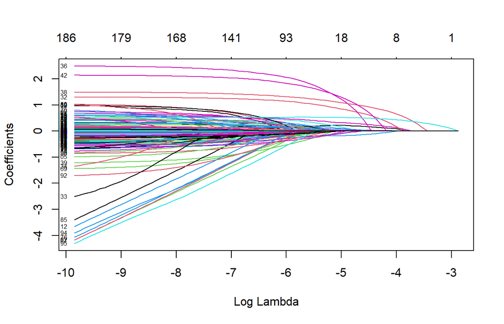

Fig. 33

```r
# Coefficient path (from original glmnet fit)
lasso <- glmnet(
  x = mm_train,
  y = train$TARGET,
  family = "binomial",
  alpha = 1, # LASSO
)

# Visualize regularization path
plot(lasso, xvar = "lambda", label = TRUE)
```

#### 7.1.0.4 Step 4: Extract non-zero coefficients

```r
coef_best <- coef(cv_lasso, s = "lambda.min")

data.frame(
  Feature = rownames(coef_best)[which(coef_best != 0)],
  Coefficient = coef_best[coef_best != 0]
)
```

```
##                                                Feature   Coefficient
## 1                                          (Intercept) -2.4997861594
## 2                                  raceAfricanAmerican  0.0170568871
## 3                                            raceAsian -0.2530674642
## 4                                            raceOther -0.2121100640
## 5                                           genderMale -0.0154331440
## 6                                                age.L  0.0902885259
## 7                                                age.C -0.1765868402
## 8                                                age^4 -0.1999887251
## 9                                                age^6  0.0015242414
## 10                                               age^7  0.0407434065
## 11                                               age^9 -0.1232465083
## 12                                            weight.L -0.3278662047
## 13                                            weight.Q -0.1066283818
## 14                                            weight.C -0.2593060935
```

[output cut: 114 more lines]

**Three possible relationships between the non-zero coefficients of the LASSO model and the key insights gained from the EDA**:

1. **Significant feature correlation**: Features with higher absolute correlation to the target in EDA such as `number_inpatient` often remain in the model. Their inclusion suggests consistency between univariate analysis and multivariate regularized modeling.
2. **Interaction with categorical variables**: Categorical predictors such as `discharge_disposition_id` that showed class imbalance or strong differences in readmission rates in EDA may remain active, confirming their discriminatory power when controlling for others.
3. **Collinearity resolution**: LASSO tends to select one feature from a group of correlated variables. If EDA showed high collinearity (e.g., between `change` and `diabetesMed`), LASSO’s sparsity helps resolve this by shrinking some to zero.

#### 7.1.0.5 Step 5: Predict and compute AUC on test data

```r
lasso_probs <- predict(cv_lasso, newx = mm_test, s = "lambda.min", type = "response")
auc_lasso <- AUC(y_pred = lasso_probs, y_true = as.numeric(test$TARGET) - 1)
cat("Test AUC (Lasso):", round(auc_lasso, 4), "\n")
```

```
## Test AUC (Lasso): 0.6881
```

## 7.2 b) L2 Regularization (Ridge Regression)

Apply the Ridge Regression method (L2 regularization) to the training data. Determine the optimal regularization parameter $λ$ using cross-validation and visualize the regularization path. Compute the AUC score of the model on the test data.

**Solution:**

We continue with the data prepared in the last session.

#### 7.2.0.1 Step 1: Train ridge regression with cross-validation

```r
# Hyperparameter tuning for Ridge via cross-validation
set.seed(seed)
cv_ridge <- cv.glmnet(
  x = mm_train,
  y = train$TARGET,
  family = "binomial",
  alpha = 0, # Ridge
  type.measure = "auc" # AUC as evaluation metric
  # nfolds = 10
)
```

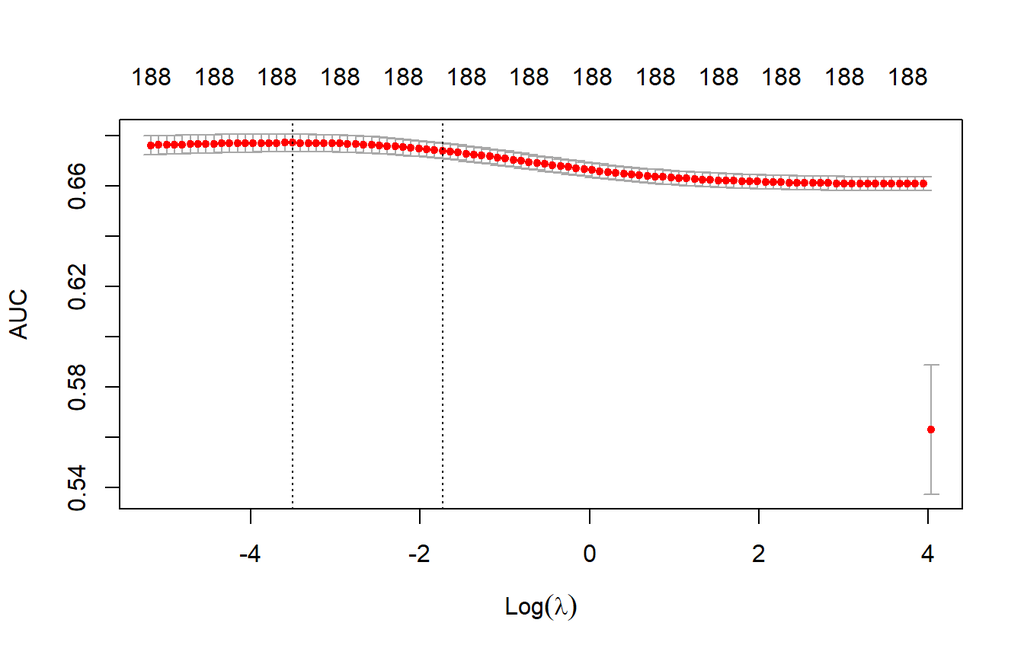

Fig. 34

```r
# Visualise cross-validated AUC vs. log(lambda)
plot(cv_ridge)
```

```r
# Optimal regularization paramter λ
best_lambda <- cv_ridge$lambda.min
cat("Optimal regularization paramter λ:", best_lambda, "\n")
```

```
## Optimal regularization paramter λ: 0.03006469
```

#### 7.2.0.2 Step 2: Visualize regularization path

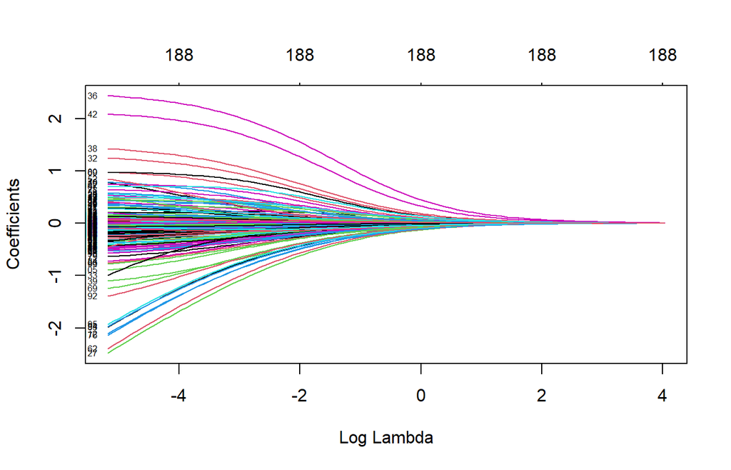

Fig. 35

```r
# Coefficient path (from original glmnet fit)
ridge <- glmnet(
  x = mm_train,
  y = train$TARGET,
  family = "binomial",
  alpha = 0, # Ridge
)

plot(ridge, xvar = "lambda", label = TRUE)
```

#### 7.2.0.3 Step 3: Predict and compute AUC on test data

```r
ridge_probs <- predict(cv_ridge, newx = mm_test, s = "lambda.min", type = "response")
auc_ridge <- AUC(y_pred = ridge_probs, y_true = as.numeric(test$TARGET) - 1)
cat("Test AUC (Ridge):", round(auc_ridge, 4), "\n")
```

```
## Test AUC (Ridge): 0.6874
```

## 7.3 c) Generalized Additive Model (GAM)

Train a Generalized Additive Model (GAM) on the training data, for example using the `mgcv` package. Design the GAM such that the AUC score achieved of this model on the test data is higher than that of the Logistic Regression model from Task R4a). Explain how the plots and curve patterns from Task R2 help identify relevant features for constructing a suitable GAM, taking into account effects that were overlooked in the previous task parts. Specify the corresponding feature candidates and visualize the estimated effects of two of these features, which have been identified as particularly promising for the GAM. Compute the AUC score of the model on the test data.

**Solution:**

#### 7.3.0.1 Step 1: Feature selection justification from EDA

From earlier exploratory data analysis (EDA), we observed that features such as `number_inpatient`, `num_lab_procedures`, and `num_medications` exhibit non-linear relationships with the target variable (TARGET). For instance, these features show that higher values are associated with increased readmission risk, but the trends are not strictly linear; they often show plateauing or threshold effects rather than a constant increase.

Such non-linear patterns are poorly captured by standard logistic regression, which assumes a linear relationship between the predictors and the log-odds of the outcome. To better model these complexities, we incorporate smooth terms for these features in a Generalized Additive Model (GAM). This allows us to flexibly capture non-linear effects without manually engineering transformations.

#### 7.3.0.2 Step 2: Fit a GAM model Using `mgcv`

```r
set.seed(seed)
# Fit GAM with smooth terms for selected features
gam <- gam(
  TARGET ~ race + age + weight + admission_type_id +
    discharge_disposition_id + admission_source_id +
    time_in_hospital + payer_code +
    medical_specialty + s(num_lab_procedures) +
    num_procedures + s(num_medications) +
    number_outpatient + number_emergency +
    s(number_inpatient) + number_diagnoses + A1Cresult +
    metformin + insulin + diabetesMed +
    group_diag_1 + group_diag_2 + group_diag_3,
  data = train,
  family = binomial(link = "logit")
)
```

```r
# Print model summary
summary(gam)
```

```
##
## Family: binomial
## Link function: logit
##
## Formula:
## TARGET ~ race + age + weight + admission_type_id + discharge_disposition_id +
##     admission_source_id + time_in_hospital + payer_code + medical_specialty +
##     s(num_lab_procedures) + num_procedures + s(num_medications) +
##     number_outpatient + number_emergency + s(number_inpatient) +
##     number_diagnoses + A1Cresult + metformin + insulin + diabetesMed +
##     group_diag_1 + group_diag_2 + group_diag_3
##
## Parametric coefficients:
##                                                         Estimate Std. Error
## (Intercept)                                           -2.667e+00  2.782e-01
## raceAfricanAmerican                                    1.744e-01  1.159e-01
## raceAsian                                             -2.848e-01  2.376e-01
## raceCaucasian                                          1.365e-01  1.099e-01
## raceHispanic                                           1.885e-01  1.588e-01
## raceOther                                             -1.919e-01  1.820e-01
## age.L                                                  2.342e-01  4.107e-01
## age.Q                                                 -2.360e-01  4.095e-01
## age.C                                                 -5.032e-02  3.535e-01
## age^4                                                 -2.877e-01  2.788e-01
## age^5                                                 -1.815e-02  2.105e-01
## age^6                                                  4.166e-02  1.560e-01
## age^7                                                  2.171e-02  1.158e-01
## age^8                                                  3.448e-02  8.747e-02
## age^9                                                 -1.821e-01  6.291e-02
## weight.L                                              -7.609e-01  5.939e-01
## weight.Q                                               4.683e-02  3.953e-01
## weight.C                                              -4.528e-01  5.090e-01
## weight^4                                               1.103e+00  6.583e-01
## weight^5                                              -1.727e-01  6.225e-01
## weight^6                                               1.554e-01  4.572e-01
## weight^7                                               5.260e-02  2.572e-01
## admission_type_id2                                     1.323e-01  6.816e-02
## admission_type_id3                                     1.892e-03  7.917e-02
## admission_type_id5                                     2.755e-01  1.119e-01
## admission_type_id6                                     4.755e-01  9.649e-02
```

[output cut: 281 more lines]

```
## group_diag_3Other                                      -1.349 0.177319
## group_diag_3Respiratory                                 1.025 0.305341
## ---
## Signif. codes:  0 '***' 0.001 '**' 0.01 '*' 0.05 '.' 0.1 ' ' 1
##
## Approximate significance of smooth terms:
##                         edf Ref.df  Chi.sq  p-value
## s(num_lab_procedures) 1.859  2.348   1.586 0.468092
## s(num_medications)    4.287  5.216  22.194 0.000579 ***
## s(number_inpatient)   3.394  4.127 410.204  < 2e-16 ***
## ---
## Signif. codes:  0 '***' 0.001 '**' 0.01 '*' 0.05 '.' 0.1 ' ' 1
##
## R-sq.(adj) =  0.0681   Deviance explained = 8.03%
## UBRE = -0.2744  Scale est. = 1         n = 33426
```

#### 7.3.0.3 Step 3: Visualize the estimated non-linear effects

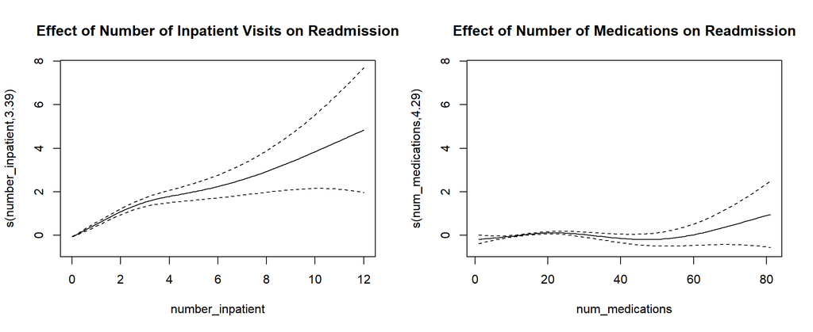

Fig. 36

```r
par(mfrow = c(1, 2))
plot(gam, select = 3, main = "Effect of Number of Inpatient Visits on Readmission")
plot(gam, select = 2, main = "Effect of Number of Medications on Readmission")
```

These plots illustrate how the log-odds of readmission vary smoothly with each variable, uncovering S-shaped or polynomial-like patterns that suggest non-linear effects.

#### 7.3.0.4 Step 4: Predict and compute AUC on test set

```r
# Predict probabilities
gam_pred <- predict(gam, newdata = test, type = "response")

# Compute AUC
auc_gam <- AUC(y_pred = gam_pred, y_true = as.numeric(test$TARGET) - 1)
cat("Test AUC (GAM):", round(auc_gam, 4), "\n")
```

```
## Test AUC (GAM): 0.6886
```

## 7.4 d) Comparison and discussion

Compare the model performance of the following approaches: – Logistic Regression without interactions from subtask R4a) – Logistic Regression with interactions from subtask R4b) – LASSO model from subtask R5a) – Ridge Regression from subtask R5b) – Generalized Additive Model from subtask R5c)

Discuss which of these models is best suited for the given prediction task and provide a justified explanation for your choice.

**Solution:**

In comparison of model performance, here are the AUC scores for each of the models:

- Logistic Regression without interactions: AUC = 0.685818;
- Logistic Regression with interactions: AUC = 0.6852429;
- LASSO Model: AUC = 0.6881011;
- Ridge Regression: AUC = 0.6874132;
- Generalized Additive Model (GAM): AUC = 0.6886033.

**Model Performance Discussion**

To assess which model is best suited for predicting hospital readmission rates, we need to consider the following aspects:

1. **AUC Score**:
   - The AUC (Area Under the Curve) score represents the model’s ability to distinguish between classes (in this case, whether a patient will be readmitted or not). A higher AUC score indicates a better model.
   - GAM has the highest AUC (0.6886033), followed closely by LASSO (0.6881011), Ridge Regression (0.6874132), and both Logistic Regression with interactions (0.6852429) and without interactions (0.685818).
2. **Model complexity and interpretability**:
   - Logistic Regression (with or without interactions) is simple to interpret. The coefficients can give insight into the relationship between the features and the outcome. Logistic regression without interactions is particularly easy to interpret but might miss complex relationships between features.
   - Logistic Regression with interactions allows for a better understanding of interactions between variables, which is important when features have complex, non-linear relationships. However, it increases complexity slightly.
   - LASSO and Ridge Regression are both regularization techniques, which reduce overfitting by penalizing large coefficients. LASSO can perform variable selection by shrinking some coefficients to zero, making it easier to identify important features. Ridge regression, on the other hand, shrinks the coefficients but does not set any of them to zero.
   - Generalized Additive Models (GAM) allow for more flexible relationships between the predictors and the target variable, as they model non-linear effects. However, GAMs are more complex to interpret compared to logistic regression models.

Which model is best suited for predicting hospital readmission rate?

- LASSO appears to be the best model for predicting hospital readmission rates based on the AUC score (0.6881011) and its ability to perform automatic feature selection, which is especially useful in a healthcare context where certain features may be irrelevant or redundant.
- While GAM performs with the best AUC and offers flexibility in modeling non-linear relationships, its complexity and lower interpretability make it less ideal for practical implementation compared to LASSO.
- Logistic regression is a close contender but still lags behind LASSO in performance and doesn’t offer the same regularization and feature selection advantages. Ridge regression has a slightly lower AUC than LASSO and doesn’t perform feature selection, making it less desirable.

# 8 Task R6: Ternary Classification

In this task, you will apply the machine learning models Multinomial Logistic Regression and XGBoost for ternary classification. The training, validation, and test datasets based on `diabetic_data_ter`, prepared in subtask R3a), will serve as input data.

## 8.1 a) Evaluation Metrics for Binary and Ternary Classification:

First, explain whether and why the AUC evaluation metric used so far is well suited for binary classification. Briefly discuss two advantages and disadvantages of AUC compared to Accuracy. Describe the key considerations when evaluating multiclass classification models. Discuss the evaluation metrics Accuracy, Balanced Accuracy, and Macro-F1 Score, and explain in which situation each of these is particularly useful. Implement a function that computes these three metrics and outputs them in a concise format.

**Solution:**

#### 8.1.0.1 1. AUC for binary classification

AUC (Area Under the Receiver Operating Characteristic Curve) is a widely used metric for binary classification tasks. It measures the model’s ability to distinguish between the two classes (e.g., readmission vs. no readmission) across different classification thresholds.

**Why AUC is well-suited for binary classification**:

- Measures discrimination ability: AUC reflects the probability that the classifier ranks a randomly chosen positive instance higher than a randomly chosen negative one. This is especially valuable in binary classification tasks like fraud detection or medical diagnosis, where the goal is to separate the positive and negative classes effectively.
- Threshold independence: AUC evaluates the model’s performance across all possible classification thresholds, not just a single point like accuracy does (e.g., threshold = 0.5). This is useful when the optimal threshold isn’t known in advance (especially in imbalanced datasets) or when the costs of false positives vs. false negatives differ.
- Robustness to class imbalance: In imbalanced datasets (common in binary classification), accuracy can be misleading (e.g., 95% accuracy by always predicting the majority class). AUC remains meaningful even when the class distribution is skewed, making it more reliable for evaluating model quality.

#### 8.1.0.2 2. Advantages and disadvantages of AUC vs. Accuracy

**Advantages of AUC**:

- Robust to class imbalance: AUC evaluates the model’s ability to distinguish resp. rank between classes regardless of their frequency. Accuracy, on the other hand, can be misleading when one class dominates (e.g., predicting the majority class yields high accuracy but poor actual performance).
- Threshold-independent: AUC evaluates the model’s performance across all possible decision thresholds, so it is not dependent on selecting a specific threshold (such as 0.5 in binary classification). This makes AUC a more robust and generalizable evaluation metric.

**Disadvantages of AUC**:

- Harder to interpret: AUC is a more abstract concept than accuracy. While accuracy tells you the percentage of correct predictions, AUC reflects performance across threshold levels, which can be less intuitive for stakeholders.
- Ignores actual operating point: AUC does not reflect model performance at a specific decision threshold. If you care about performance at a particular threshold (e.g., 0.5), accuracy or metrics like precision/recall are more relevant.

#### 8.1.0.3 3. Key Considerations for evaluating multiclass classification models

In multiclass classification, the model needs to distinguish among three or more classes (e.g., different medical conditions or diagnoses). Evaluating these models is more complex than binary classification, and different metrics are required.

**Key considerations**:

- Class imbalance: Like in binary classification, classes may be imbalanced, which can affect model performance. A naive classifier may achieve high accuracy by favoring majority classes, while performing poorly on minority ones. A solution is to use metrics like balanced accuracy, macro-averaged F1, or per-class recall to account for this.
- Multiple metrics: Instead of just focusing on accuracy, we must consider other metrics that can provide a clearer picture of how well the model is doing for **each individual class**.
- Averaging methods: Metrics such as precision, recall, and F1 can be averaged in different ways:
  - Macro averaging: Treats all classes equally, regardless of support (size). Good for imbalanced datasets when every class matters.
  - Micro averaging: Aggregates over all instances, favouring performance on common classes.
  - Weighted averaging: Weights each class’s metric by its frequency in the dataset.
- Interpretability: Global accuracy is simple but may not explain model behavior for individual classes. Reporting per-class performance gives insight into which classes the model struggles with.
- Confusion Matrix: Useful for visualizing the distribution of prediction errors across classes. Helps identify specific classes that are being confused with others.
- Domain-Specific costs: Misclassification may have different consequences depending on the class (e.g., misdiagnosing a disease vs. a healthy case). In such cases, cost-sensitive evaluation or custom scoring rules may be needed.

##### 8.1.0.3.1 4. Explanation of Evaluation Metrics

**Accuracy**:

- Accuracy measures the proportion of correctly classified instances out of all instances. However, it can be misleading if the classes are imbalanced.

$$\text{Accuracy} = \frac{\text{Number of Correct
Predictions}}{\text{Total Number of Predictions}}$$

- **Use case**: Accuracy is useful when the classes are balanced and misclassification costs are roughly equal.

**Balanced Accuracy**:

- Balanced Accuracy is calculated as the average recall (true positive rate) across all classes:

$$\text{Balanced Accuracy} = \frac{1}{N} \sum_{i=1}^{N} \text{Recall}_i$$
where $N$ is the number of classes.

- **Use case**: This metric is useful for imbalanced datasets, as it gives equal importance to each class regardless of its frequency.

**Macro-F1 Score**:

- The F1 score is the harmonic mean of precision and recall, which balances precision and recall. The **Macro-F1 Score** is the average F1 score over all classes:

$$\text{Macro-F1} = \frac{1}{N} \sum_{i=1}^{N} \text{F1}_i$$

where:

$$\text{F1}_i = 2 \cdot \frac{\text{Precision}_i \cdot
\text{Recall}_i}{\text{Precision}_i + \text{Recall}_i}$$

and $N$ is the number of classes.

- **Use case**: Macro-F1 is especially useful when all classes should be treated equally, as well as where balancing false positives and false negatives across all classes is of interest.

##### 8.1.0.3.2 5. Implementing a Function for Accuracy, Balanced Accuracy, and Macro-F1 Score

Now we implement a function that computes Accuracy, Balanced Accuracy, and Macro-F1 Score:

```r
# Function to compute Accuracy, Balanced Accuracy, and Macro-F1 Score
compute_metrics <- function(y_pred, y_true) {

  # Confusion matrix
  cm <- confusionMatrix(y_pred, y_true)

  # Accuracy
  accuracy <- cm$overall['Accuracy']

  # Balanced Accuracy
  balanced_accuracy <- mean(cm$byClass[, 'Balanced Accuracy'])

  # Macro-F1 Score
  macro_f1 <- mean(cm$byClass[, 'F1'])

  # Output in a concise format
  result <- data.frame(
    Accuracy = accuracy,
    Balanced_Accuracy = balanced_accuracy,
    Macro_F1_Score = macro_f1)

  return(result)
}
```

## 8.2 b) Ternary Classification with Multinomial Logistic Regression

Train a Multinomial Logistic Regression model (e.g., using the `multinom` function from the `nnet` package) on the training dataset. Select only features that have at least two distinct values, and exclude the target variable as well as the diagnosis columns (`diag_1`, `diag_2`, `diag_3`). Optimize the class thresholds to ensure that the predicted class distribution closely matches the actual distribution of TARGET. Evaluate the model’s performance on the test dataset using the optimized thresholds and the function from subtask R6a). Additionally, generate and interpret an appropriate confusion matrix that compares the model’s predictions with the actual values in the test data.

**Solution:**

#### 8.2.0.1 Step 1: Data preprocessing

```r
train_ter <- feature_selection(diabetic_data_ter_splitted$train)
valid_ter <- feature_selection(diabetic_data_ter_splitted$valid)
test_ter <- feature_selection(diabetic_data_ter_splitted$test)
```

#### 8.2.0.2 Step 2: Train the multinomial logistic regression model

```r
multinom <- nnet::multinom(TARGET ~ ., data = train_ter)
```

#### 8.2.0.3 Step 3: Obtain predicted and actual class distributions on the validation dataset to tune the classification thresholds

```r
# Probabilities for each class
multinom_probs <- predict(multinom, newdata = valid_ter, type = "probs")

# Actual distribution
actual_dist <- prop.table(table(valid_ter$TARGET))
```

Here `multinom_probs` is a matrix where each column is a class and each row is a sample.

#### 8.2.0.4 Step 4: Optimize class thresholds using weighting

Threshold optimization helps mitigate bias toward the majority class. This is particularly useful in imbalanced multiclass classification, as is the case here. Adjusting class thresholds post-prediction can improve performance by aligning predicted class proportions with observed class frequencies. This method is most effective when the predicted class probabilities are well-calibrated.

For a multinomial logistic regression model with three classes, optimizing thresholds involves adjusting decision boundaries such that the predicted class distribution better reflects the actual class distribution in the validation set.

To achieve this, we implement a function that finds optimal class-specific thresholds. One practical approach is to apply class weights that scale predicted probabilities, shifting the decision rule accordingly.

```r
# Get predicted classes under default max-prob rule
default_pred <- apply(multinom_probs, 1, which.max)

# Get class names
class_names <- colnames(multinom_probs)

# Function to assign class using weighted probabilities
assign_weighted_class <- function(probs, weights) {
  weighted_probs <- t(t(probs) * weights)
  factor(apply(weighted_probs, 1, function(x) class_names[which.max(x)]),
         levels = levels(train_ter$TARGET))
}

# Grid search for weights that bring predicted distribution closer to actual
grid <- expand.grid(w1 = seq(0.1, 1.5, 0.1),
                    w2 = seq(0.1, 1.5, 0.1),
                    w3 = seq(0.1, 1.5, 0.1))

grid$distance <- NA

for (i in 1:nrow(grid)) {
  w <- as.numeric(grid[i, 1:3])
  preds <- assign_weighted_class(multinom_probs, w)
  dist <- sum((prop.table(table(preds)) - actual_dist)^2)
  grid$distance[i] <- dist
}

# Best weights
best_weights <- as.numeric(grid[which.min(grid$distance), 1:3])
names(best_weights) <- class_names
print(best_weights)
```

```
##  NO <30 >30
## 0.3 1.2 0.5
```

#### 8.2.0.5 Step 5: Evaluate the model’s performance on the test dataset

```r
# Predict classes using optimized thresholds
pred_probs <- predict(multinom, newdata = test_ter, type = "probs")
pred_classes <- assign_weighted_class(pred_probs, best_weights)

# Evaluate the model's performance via the computed metrics
compute_metrics(test_ter$TARGET, pred_classes)
```

```
##           Accuracy Balanced_Accuracy Macro_F1_Score
## Accuracy 0.5565507         0.5815716      0.4330577
```

#### 8.2.0.6 Step 6: Generate and interpret confusion matrix

```r
# Create and print confusion matrix
confusionMatrix(pred_classes, test_ter$TARGET)
```

```
## Confusion Matrix and Statistics
##
##           Reference
## Prediction   NO  <30  >30
##        NO  4179  434 1556
##        <30  389  165  280
##        >30 1653  342 1497
##
## Overall Statistics
##
##                Accuracy : 0.5566
##                  95% CI : (0.547, 0.5661)
##     No Information Rate : 0.5928
##     P-Value [Acc > NIR] : 1.000
##
##                   Kappa : 0.1769
##
##  Mcnemar's Test P-Value : 0.009
##
## Statistics by Class:
##
##                      Class: NO Class: <30 Class: >30
## Sensitivity             0.6718    0.17535     0.4491
## Specificity             0.5344    0.92998     0.7214
## Pos Pred Value          0.6774    0.19784     0.4287
## Neg Pred Value          0.5280    0.91968     0.7378
## Prevalence              0.5928    0.08966     0.3176
## Detection Rate          0.3982    0.01572     0.1426
## Detection Prevalence    0.5878    0.07947     0.3327
## Balanced Accuracy       0.6031    0.55266     0.5853
```

**Key metrics summary**

1. **Overall performance**:
   - Accuracy: 0.5566 → 55.66% of all predictions are correct.
   - Kappa: 0.1769 → Suggests only slight agreement beyond chance.
   - P-value [Acc > NIR]: 1.0 → Model does not significantly outperform guessing the majority class (“NO”).
2. **Class: NO**:
   - High sensitivity (67.2%) → captures most actual NO cases.
   - But specificity is low (53.4%) → many false positives (non-NO predicted as NO).
   - Precision is decent (67.7%) → predicted NO is correct 2/3 of the time.
3. **Class: <30**:
   - Extremely low sensitivity (17.5%) → model misses most true <30 cases.
   - High specificity (93.0%) → model avoids false alarms well.
   - Precision (19.8%) → among the few predictions as <30, only ~20% are correct.
4. **Class: >30**:
   - Moderate sensitivity (44.9%) → detects ~45% of actual >30 cases.
   - Specificity (72%) is acceptable.
   - Precision (42.9%) is better than <30, but still shows room for improvement.

We observe an imbalanced prediction bias: most predictions fall into the majority classes (NO or >30), while the <30 class is poorly predicted, exhibiting low recall and precision, even when using the optimal threshold.

## 8.3 c) Ternary Classification with XGBoost

Train an XGBoost model, analogous to subtask R3b). Optimize the class thresholds to ensure that the predicted class distribution closely matches the actual distribution of TARGET. Evaluate the model’s performance on the test dataset using the optimized thresholds and the function from subtask R6a). Additionally, generate and interpret an appropriate confusion matrix that compares the model’s predictions with the actual values in the test data. Compare the results with those from subtask R6b) and discuss which model (Multinomial Logistic Regression or XGBoost) is better suited for this problem, based on model performance and the confusion matrix.

**Solution:**

#### 8.3.0.1 Step 1: Prepare the data

In order for *XGBoost* to properly ingest our data samples we need to re-format them slightly:

```r
# Feature formatting
xgb_train <- process_data_for_xgboost(diabetic_data_ter_splitted$train)
xgb_valid <- process_data_for_xgboost(diabetic_data_ter_splitted$valid)
xgb_test <- process_data_for_xgboost(diabetic_data_ter_splitted$test)

dtrain <- xgb.DMatrix(xgb_train$dat_x,label = xgb_train$dat_y)
dvalid <- xgb.DMatrix(xgb_valid$dat_x,label = xgb_valid$dat_y)
dtest <- xgb.DMatrix(xgb_test$dat_x)
```

#### 8.3.0.2 Step 2: Define hyperparameter grid

We specify the grid of hyperparameters to search over. Again this and the next steps are commented out in subsequent runs after identifying the best parameters in the initial run, in order to save compilation time when knitting the report to HTML.

```r
# # Define hyperparameter grid
# xgb_grid <- expand.grid(
#   colsample_bytree = c(0.6, 0.8, 1.0),
#   subsample = c(0.6, 0.8, 1.0),
#   max_depth = c(3, 5, 7),
#   eta = c(0.01, 0.1, 0.5)
# )
#
# # Randomly sample 30 parameter combinations
# set.seed(seed)
# xgb_grid <- xgb_grid[sample(nrow(xgb_grid), 30), ]
```

#### 8.3.0.3 Step 3: Perform cross-validation

For each combination of hyperparameters, we use `xgb.cv` to perform a 5-fold cross-validation (CV) step to measure our model’s performance.

```r
# # Initialize progress bar and set the seed
# pb <- txtProgressBar(min = 0, max = nrow(xgb_grid), style = 3)
# set.seed(seed)
#
# # Loop over each combination of hyperparameters
# for (i in 1:nrow(xgb_grid)) {
#   # Set XGBoost parameters
#   xgb_params <- list(colsample_bytree = xgb_grid$colsample_bytree[i], # variables per tree
#                    subsample = xgb_grid$subsample[i], # data subset per tree
#                    booster = "gbtree",
#                    max_depth = xgb_grid$max_depth[i], # tree levels
#                    eta = xgb_grid$eta[i], # shrinkage
#                    objective = "multi:softprob",
#                    eval_metric = "mlogloss",
#                    num_class = 3)
#
#   xgb_cv <- xgb.cv(xgb_params,
#                    dtrain,
#                    nrounds = 200,
#                    nfold = 5,
#                    verbose = FALSE,
#                    early_stopping_rounds = 5)
#
#   # Get the auc score
#   xgb_grid$mlogloss[i] <- min(xgb_cv$evaluation_log$test_mlogloss_mean)
#
#   # Update progress bar
#   setTxtProgressBar(pb, i)
# }
#
# # Close progress bar
# close(pb)
#
# # Store the best parameters
# best_params <- xgb_grid[which.min(xgb_grid$mlogloss), ]
```

#### 8.3.0.4 Step 4: Train the final model

Having found the best parameters and features during cross-validation, we can now train our classifier.

```r
# The best hyperparameters found in the initial run
best_params <- data.frame(colsample_bytree = 0.6,
                          subsample = 0.8,
                          max_depth = 7,
                          eta = 0.1)
# Set XGBoost parameters
xgb_params <- list(colsample_bytree = best_params$colsample_bytree, # variables per tree
                   subsample = best_params$subsample, # data subset per tree
                   booster = "gbtree",
                   max_depth = best_params$max_depth, # tree levels
                   eta = best_params$eta, # shrinkage
                   objective = "multi:softprob",
                   eval_metric = "mlogloss",
                   num_class = 3
                   )

# Define watchlist to monitor training and validation error
watchlist <- list(train = dtrain, valid = dvalid)

# Train the XGBoost
set.seed(seed)
xgb <- xgb.train(params = xgb_params,
                 data = dtrain,
                 print_every_n = 5,
                 watchlist = watchlist,
                 nrounds = 120,
                 early_stopping_rounds = 5)
```

[output not shown]

#### 8.3.0.5 Step 5: Predict class probabilities on validation data for class threshold optimization later

```r
pred_probs <- predict(xgb, dvalid)
pred_matrix <- matrix(pred_probs, ncol = 3, byrow = TRUE)

# Actual validation class distribution
actual_dist <- prop.table(table(xgb_valid$dat_y))
```

#### 8.3.0.6 Step 6: Optimize class thresholds

This step finds the optimal class thresholds so predicted class frequencies match actual frequencies.

```r
threshold_opt <- function(thresholds, probs, actual_dist) {
  pred_class <- apply(probs, 1, function(p) {
    if (p[1] >= thresholds[1]) return(0)
    else if (p[2] >= thresholds[2]) return(1)
    else return(2)
  })
  pred_dist <- prop.table(table(factor(pred_class, levels = 0:2)))
  sum((pred_dist - actual_dist)^2)  # L2 norm between distributions
}

set.seed(seed)
# Initial thresholds
init_thresh <- c(0.6, 0.3)
opt_res <- optim(init_thresh,
                 threshold_opt, probs = pred_matrix, actual_dist = actual_dist,
                 method = "L-BFGS-B", lower = c(0.01, 0.01), upper = c(0.99, 0.99))

best_thresh <- opt_res$par
```

#### 8.3.0.7 Step 7: Evaluate the model’s performance on the test dataset

```r
# Predict probabilities on test data
test_probs <- predict(xgb, dtest)
test_matrix <- matrix(test_probs, ncol = 3, byrow = TRUE)

# Predict classes using optimized thresholds
test_pred <- apply(test_matrix, 1, function(p) {
  if (p[1] >= best_thresh[1]) return(0)
  else if (p[2] >= best_thresh[2]) return(1)
  else return(2)
})

# Evaluate the model's performance via the computed metrics
compute_metrics(factor(xgb_test$dat_y, levels = 0:2),
                factor(test_pred, levels = 0:2))
```

```
##          Accuracy Balanced_Accuracy Macro_F1_Score
## Accuracy 0.594283         0.6263205      0.4221972
```

```r
# Generarate confusion matrix
confusionMatrix(
  factor(test_pred, levels = 0:2),
  factor(xgb_test$dat_y, levels = 0:2))
```

```
## Confusion Matrix and Statistics
##
##           Reference
## Prediction    0    1    2
##          0 4536  451 1641
##          1   33   50   41
##          2 1652  440 1651
##
## Overall Statistics
##
##                Accuracy : 0.5943
##                  95% CI : (0.5848, 0.6037)
##     No Information Rate : 0.5928
##     P-Value [Acc > NIR] : 0.3793
##
##                   Kappa : 0.2065
##
##  Mcnemar's Test P-Value : <2e-16
##
## Statistics by Class:
##
##                      Class: 0 Class: 1 Class: 2
## Sensitivity            0.7291 0.053135   0.4953
## Specificity            0.5105 0.992255   0.7079
## Pos Pred Value         0.6844 0.403226   0.4411
## Neg Pred Value         0.5643 0.914087   0.7509
## Prevalence             0.5928 0.089662   0.3176
## Detection Rate         0.4322 0.004764   0.1573
## Detection Prevalence   0.6315 0.011815   0.3566
## Balanced Accuracy      0.6198 0.522695   0.6016
```

**Key observations**

- **Class 0 (“No readmission”)**:
  - High sensitivity (0.73): the model correctly identifies most patients who will not be readmitted.
  - But specificity is low (0.51), meaning it often misclassifies readmitted patients as “no readmission”.
- **Class 1 (“<30 days”)**:
  - Very poor sensitivity (0.053): only ~5% of actual “<30” readmissions are detected.
  - However, excellent specificity (0.99): almost no non-“<30” patients are incorrectly flagged.
- **Class 2 (“>30 days”)**:
  - Balanced performance: sensitivity (0.50), specificity (0.71), balanced accuracy (0.60).
  - Better than Class 1 but still far from ideal.

**Summary of Model Performance Comparison**

For the task of equally differentiating between the three readmission classes, **no readmission**, **readmission within 30 days**, and **readmission after 30 days**, XGBoost is generally better suited due to:

- Slightly higher overall and balanced accuracy;
- Improved precision (positive predictive value) across all classes;
- Greater robustness in identifying the “>30 days” class

However, there is a critical limitation:

- Both models perform poorly on Class 1 (“<30 days”), which represents the most clinically significant group for early intervention.
- XGBoost in particular shows notably low sensitivity for this class (5.3% vs. 17.5% for Multinomial Logistic Regression).

Given that accurately detecting readmission within 30 days is the primary goal, Multinomial Logistic Regression emerges as the more appropriate model, despite its lower overall accuracy.

## 8.4 d) One-vs-One

Another way to evaluate the model is by calculating the AUC score per class, using a pairwise (One-vs-One) approach. Perform a One-vs-One analysis for the Multinomial Logistic Regression model from subtask R6b), where each possible pair of classes in TARGET is treated as a separate binary classification problem, and compute the AUC score for each pair using the test data. Compare and interpret the One-vs-One results, both among themselves and in relation to the results from the Logistic Regression model from Task R4 (binary classification: $<30$ vs. NO).

**Solution:**

```r
# Predict class probabilities from the multinomial model
pred_probs <- predict(multinom, newdata = test_ter, type = "probs")

# COnvert `pred_probs` to a data frame with class probabilities
df_probs <- as.data.frame(pred_probs)
df_probs$true_class <- test_ter$TARGET

# Get all class pairs for One-vs-One
class_pairs <- combn(colnames(df_probs)[colnames(df_probs) != "true_class"], 2, simplify = FALSE)

# Function to compute AUC for each class pair using predicted probabilities
compute_ovo_auc <- function(pair, prob_data) {
  class1 <- pair[1]
  class2 <- pair[2]

  # Filter only observations from class1 or class2
  pair_data <- prob_data %>% filter(true_class %in% c(class1, class2))

  # True binary label: class2 as positive
  binary_label <- factor(pair_data$true_class, levels = c(class1, class2))

  # Score: predicted probability of class2
  score <- pair_data[[class2]]

  # Compute AUC
  auc_score <- AUC(y_pred = score, y_true = as.numeric(binary_label) - 1)

  return(data.frame(Pair = paste(class1, "vs", class2), AUC = auc_score))
}

# Apply to all pairs
ovo_auc_results <- do.call(rbind,
                           lapply(class_pairs, compute_ovo_auc, prob_data = df_probs))

# Print the results
print(ovo_auc_results)
```

```
##         Pair       AUC
## 1  NO vs <30 0.6550155
## 2  NO vs >30 0.6495335
## 3 <30 vs >30 0.5482317
```

**Comparison of One-vs-One results**:

**Compared with binary classification**:

The OvO AUC between `NO` and `<30` can now be compared to AUC score of the previous binary logistic model for that same pair, which is 0.685818. We see that the multinomial model’s AUC is worse than the binary model, suggesting that the presence of the third class confuses the model for that pair, and a binary classifier might be more focused.

**Summary**:

OvO analysis allows to zoom in on model performance for each class pair. This is particularly useful when one class (like early readmission `<30`) is of greater clinical importance. Combined with the binary classification result, this gives a full picture of how well the model is achieving the core goal.

## 8.5 e) Conclusion

Summarize your findings, addressing the following questions: What conclusions can be drawn from the results? What added value does ternary classification provide? How should the difference between the data basis for binary and ternary classification be assessed? Which models would you recommend in conclusion?

**Solution:**

#### 8.5.0.2 2. What added value does ternary classification provide?

Ternary classification (predicting among `<30`, `>30`, and `NO`) offers several advantages: - It reflects the real-world clinical decision-making context more closely than binary classification, where distinguishing among all outcomes can guide different interventions (e.g., urgent vs. planned vs. no readmission). - Enables the model to capture inter-class relationships and conditional dependencies that may not be visible in a binary setup. - Provides more granular insights, allowing stakeholders to prioritize resources based on more detailed predictions (e.g., target `<30` with highest risk scores).

#### 8.5.0.3 3. How should the difference between the data basis for binary and ternary classification be assessed?

- In binary classification, instances belonging to one class are excluded (e.g., excluding `>30` when comparing `<30` vs. `NO`), which can simplify the learning task but also reduces available data.
- Ternary models leverage all data, allowing the model to learn from a broader distribution but making the classification task inherently harder due to greater class overlap and ambiguity.
- The AUC comparison shows that including a third class introduces complexity and may reduce performance on pairwise class separation, but the holistic understanding and broader decision support it offers is valuable.

#### 8.5.0.4 4. Which models would you recommend in conclusion?

Based on the trade-offs observed:

- If the primary goal is to accurately flag early readmissions (`<30`), a binary logistic regression or LASSO model focused on `<30` vs. `NO` is recommended. These models yield high AUC and focused performance, making them ideal for this task.
- If your objective includes understanding and predicting all readmission types, a multinomial logistic regression model offers greater interpretability and practical value, especially when paired with One-vs-One evaluation and probability thresholds.

For the best balance, we can use the ternary model operationally, while incorporating a binary model as a supplementary tool to focus on high-risk `<30` predictions.